# Comprehensive Exam

## Coding Artifact

Kalin Gibbons

Nov 20, 2020

## Data Exploration

We can begin by loading the datasets from MATLAB binary files. Following that we can take a look at the predictor distributions within the training and test sets, and confirm that the Latin hypercube and uniform sampling successfully covered the design space.

```python
import os
import sys
import math
import logging
from pathlib import Path

import numpy as np
import scipy as sp
import scipy.io as spio
import sklearn
import statsmodels.api as sm
from statsmodels.formula.api import ols

%load_ext autoreload
%autoreload 2

import matplotlib as mpl
import matplotlib.pyplot as plt
%matplotlib inline
%config InlineBackend.figure_format = 'retina'

import seaborn as sns
import pandas as pd

import artifact
from artifact.datasets import load_tkr
```

```python
sns.set_context("poster")
sns.set(rc={'figure.figsize': (16, 9.)})
sns.set_style("whitegrid")


pd.set_option("display.max_rows", 120)
pd.set_option("display.max_columns", 120)

logging.basicConfig(level=logging.INFO, stream=sys.stdout)
```

|  | fem_rad_dist | fem_rad_post | fem_rad_cor | tib_ant_conf | tib_post_conf | tib_cor_conf | troch_ang | troch_offset | fem_ie | fem_vv | tib_slope | tib_ie | tib_vv |
| --- | --- | --- | --- | --- | --- | --- | --- | --- | --- | --- | --- | --- | --- |
| count | 118.000000 | 118.000000 | 118.000000 | 118.000000 | 118.000000 | 118.000000 | 118.000000 | 118.000000 | 118.000000 | 118.000000 | 118.000000 | 118.000000 | 118.000000 |
| mean | 34.679318 | 34.699880 | 25.076654 | 0.576447 | 0.566606 | 0.566455 | 12.136250 | 0.114613 | 2.500913 | 3.022945 | 5.425695 | 3.085065 | 2.661978 |
| std | 8.758003 | 8.621422 | 5.704977 | 0.250227 | 0.238158 | 0.245048 | 2.824428 | 1.712926 | 1.642112 | 2.274754 | 3.234259 | 6.989610 | 2.581382 |
| min | 20.023275 | 20.147794 | 15.057473 | 0.156412 | 0.155033 | 0.156521 | 7.041533 | -2.971073 | -0.170765 | -0.783379 | 0.036042 | -9.262953 | -1.779404 |
| 25% | 27.041186 | 27.269871 | 20.366485 | 0.354636 | 0.361475 | 0.359228 | 9.843074 | -1.294510 | 1.075247 | 1.088741 | 2.620300 | -2.984869 | 0.510166 |
| 50% | 34.258993 | 34.511098 | 25.152767 | 0.575742 | 0.563610 | 0.562852 | 12.127442 | 0.174195 | 2.387321 | 2.952512 | 5.342771 | 2.959171 | 2.601794 |
| 75% | 41.952856 | 42.077240 | 29.869907 | 0.791103 | 0.766385 | 0.781211 | 14.543464 | 1.525529 | 3.916163 | 4.921073 | 8.030905 | 8.935175 | 4.867703 |
| max | 49.991960 | 49.856998 | 34.874884 | 0.996963 | 0.987700 | 0.998975 | 16.950999 | 2.959107 | 5.361260 | 7.158789 | 11.128010 | 15.324681 | 7.176948 |

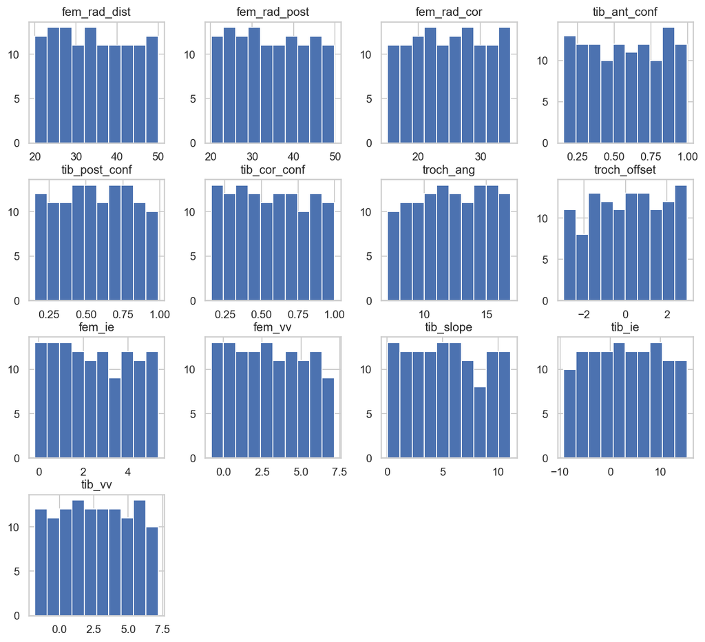

```python
# Load and describe the training data
tkr_train = artifact.Results(load_fcn=load_tkr,
                             subset='train')
tkr_train.describe_features()
plt.show()
```

|  | fem_rad_dist | fem_rad_post | fem_rad_cor | tib_ant_conf | tib_post_conf | tib_cor_conf | troch_ang | troch_offset | fem_ie | fem_vv | tib_slope | tib_ie | tib_vv |
| --- | --- | --- | --- | --- | --- | --- | --- | --- | --- | --- | --- | --- | --- |
| count | 87.000000 | 87.000000 | 87.000000 | 87.000000 | 87.000000 | 87.000000 | 87.000000 | 87.000000 | 87.000000 | 87.000000 | 87.000000 | 87.000000 | 87.00000 |
| mean | 36.721494 | 33.921034 | 24.979885 | 0.562414 | 0.560000 | 0.579770 | 12.434598 | -0.134368 | 2.234943 | 3.218851 | 5.608621 | 3.899770 | 2.98977 |
| std | 8.744665 | 8.471627 | 5.585225 | 0.251807 | 0.199884 | 0.227484 | 3.100123 | 1.744195 | 1.441232 | 2.176192 | 3.220880 | 6.935808 | 2.67016 |
| min | 20.360000 | 20.140000 | 15.570000 | 0.160000 | 0.160000 | 0.170000 | 7.010000 | -2.920000 | 0.130000 | -0.640000 | 0.200000 | -9.160000 | -1.61000 |
| 25% | 28.465000 | 26.270000 | 19.980000 | 0.330000 | 0.390000 | 0.380000 | 9.275000 | -1.785000 | 0.925000 | 1.390000 | 2.875000 | -1.240000 | 0.77500 |
| 50% | 37.560000 | 33.280000 | 24.770000 | 0.560000 | 0.550000 | 0.590000 | 12.860000 | -0.090000 | 2.070000 | 2.860000 | 5.730000 | 4.420000 | 3.14000 |
| 75% | 43.935000 | 41.315000 | 29.515000 | 0.765000 | 0.720000 | 0.785000 | 15.435000 | 1.430000 | 3.520000 | 5.145000 | 8.130000 | 9.670000 | 5.37500 |
| max | 49.120000 | 49.880000 | 34.590000 | 1.000000 | 0.950000 | 0.990000 | 16.900000 | 2.970000 | 5.200000 | 7.100000 | 11.170000 | 15.340000 | 7.06000 |

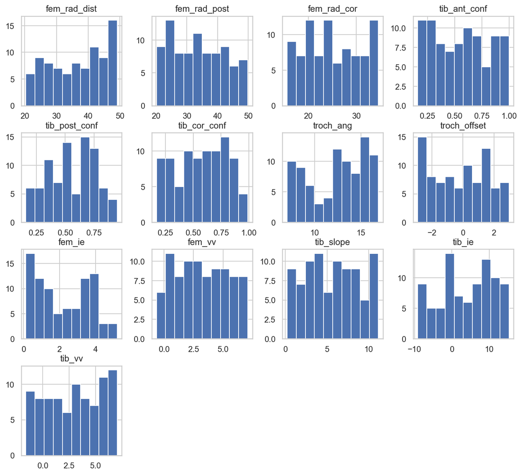

```python
# Load and describe the test space
tkr_test = artifact.Results(load_fcn=load_tkr,
                            subset='test')
tkr_test.describe_features()
plt.show()
```

It looks like the LHS did a good job of covering all of the design space for our training set, but our histograms are looking less uniform for the testing set. The parameter for the offset of the trochlear groove in particular seem right-skewed. We can lean on domain knowledge to guess that a positive offset lead to more simulation failures, which we have already removed. This makes sense because your trochlear groove is a smooth asymmetrical surface that your patella (kneecap) rides in, and moving this in a way that compounds the effect of asymmetrical vasti muscle distribution would increase the likelihood of patellar dislocation during, making simulated patient fail to complete their deep-knee-bend. A negative offset most likely reduced the risk of these dislocations, while a positive offset had the opposite effect. We'll skip going back and checking the histograms before removing the empty rows; that's a problem for the FEA modeler.

### Ranking Feature Importances

This dataset began with 15 features, but cam radius and femoral flexion-extension were removed after being found to be the least important. Let's check how the other features rank.

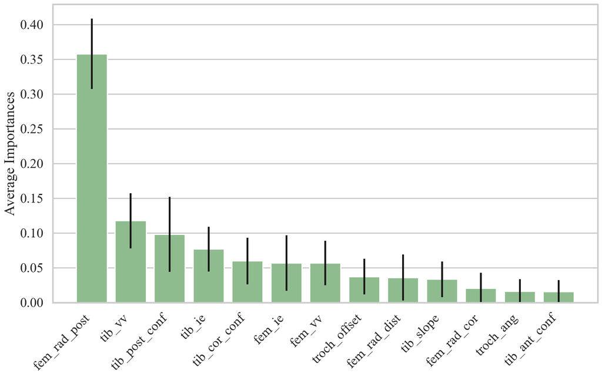

```python
sns.set_theme('poster', 'whitegrid', font='Times New Roman')
tkr_train.plot_feature_importances()
plt.gca().grid(which='major', axis='x')  # seaborn bug?
plt.show()
```

Some of those features don't seem very important. Let's try running principal component analysis on this dataset to see how quickly we're capturing variance.

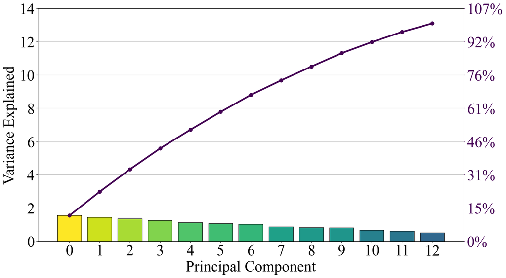

```python
sns.reset_orig()
mpl.rcParams['mathtext.fontset'] = 'stix'
mpl.rcParams['font.size'] = 32
mpl.rcParams['font.family'] = 'Times New Roman'
plt.rcParams['figure.figsize'] = (16, 9)
plt.rcParams['lines.linewidth'] = 3.5
plt.rcParams['lines.markersize'] = 15

tkr_train.plot_feature_pca()
plt.show()
```

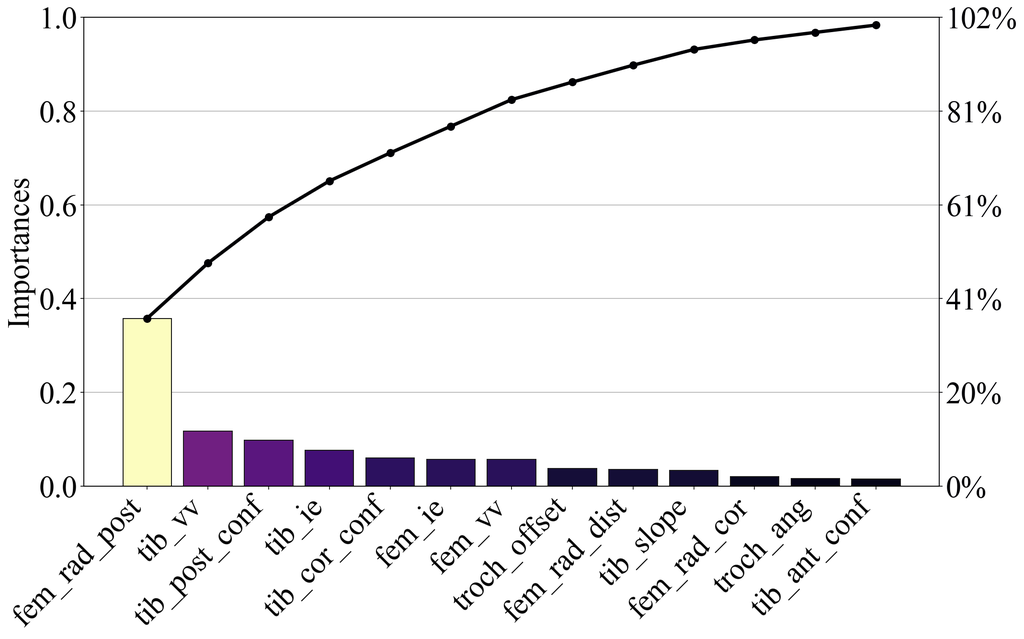

```python
tkr_train.plot_feature_importances(use_pareto=True)
plt.show()
```

Looks like each variable is contributing about the same amount to the overall variance of this feature data, but we've picked up about 80% of the importance by the sixth feature. We're performing regression instead of classification, so the importance plots holds more weight for our use case. We'll leave them in because I want to make a comparison to some earlier results from looking at this problem in 2017.

Return to the root Coding Artifact document.